# Przewidywanie właściwości sekwencji biologicznych w oparciu o analizę n-gramów

28-06-2016

## Bioinformatyczne przewidywanie właściwości sekwencji biologicznych

Prace eksperymentalne zazwyczaj poprzedza się analizami komputerowymi, które pozwalają optymalniej zaprojektować dalsze badania.

Przykłady analiz sekwencji nukleotydowych i aminokwasowych:

- przewidywanie lokalizacji subkomórkowej białek (sygnałów kierujących),
- predykcja struktury drugorzędowej i trzeciorzędowej białek oraz kwasów nukleinowych,
- wykrywanie miejsc wiązania czynników transkrypcyjnych,
- poszukiwanie sekwencji kodujących białko.

## Bioinformatyczne przewidywanie właściwości sekwencji biologicznych

Istnieją zagadnienia, dla których dotychczas istniejące metody są nieskuteczne lub dostarczają trudno interpretowalne rezultaty nie odnosząc się do biologicznych mechanizmów.

## Cel pracy doktorskiej

Opracowanie interpretowalnych metod przewidywania właściwości sekwencji biologicznych opartych na analizie n-gramów.

Wybrane zastosowania:

- przewidywanie białek amyloidogennych,
- przewidywanie nietypowych sekwencji sygnałowych.

## Białka amyloidowe

Białka związane z licznymi chorobami (np. choroby Alzheimera, Parkinsona, Creutzfeldta-Jakoba) tworzące szkodliwe agregaty.

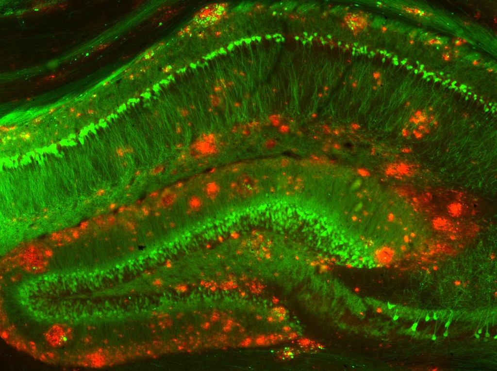

Agregaty amyloid (czerwony) wokół neuronów (zielony). Strittmatter Laboratory, Yale University

## Hot spots

Proces ten jest inicjowany w obrębie tzw. hot spots, krótkich (6-15 aminokwasów), ale zróżnicowanych podsekwencji, które występują we wszystkich białkach amyloidowych i formują specyficzne struktury \(\beta\) typu "zamka błyskawicznego" (zipper-like).

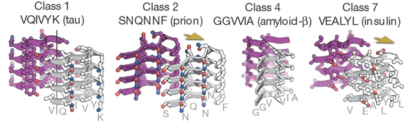

Sawaya et al. (2007)

## Zastosowanie metody n-gramów: przewidywanie białek amyloidogennych

Motywacja:

- rola białek amyloidogennych w chorobach neurodegeneracyjnych,
- niska precyzja innych programów przewidujących białka amyloidowe,
- trudno interpretowalne reguły decyzyjne wykorzystywane przez inne programy.

## Programy przewidujące lokalizację hot spots

Zróżnicowanie budowy hot spots uniemożliwa opisanie ich konkretnych wzorcem.

Istnieją już programy przewidujące miejsca inicjacji agregacji:

- APPNN (Familia et al. 2015),
- PASTA2 (Walsh et al. 2014),
- FoldAmyloid (Garbuzynskiy, Lobanov, and Galzitskaya 2010).

Precyzja tych programów nie jest wysoka, a wykorzystywane przez nie reguły decyzyjne są trudno interpretowalne.

## n-gramy

Przykładowe sekwencje. S - sekwencja, P - pozycja.

|  | P1 | P2 | P3 | P4 | P5 | P6 |
| --- | --- | --- | --- | --- | --- | --- |
| S1 | G | W | W | C | Q | L |
| S2 | I | F | Q | F | I | R |
| S3 | N | V | P | E | S | Y |

### 1-gramy:

### G, I, N

## n-gramy

Przykładowe sekwencje. S - sekwencja, P - pozycja.

|  | P1 | P2 | P3 | P4 | P5 | P6 |
| --- | --- | --- | --- | --- | --- | --- |
| S1 | G | W | W | C | Q | L |
| S2 | I | F | Q | F | I | R |
| S3 | N | V | P | E | S | Y |

### 2-gramy:

### GW, IF, NV

## n-gramy

Przykładowe sekwencje. S - sekwencja, P - pozycja.

|  | P1 | P2 | P3 | P4 | P5 | P6 |
| --- | --- | --- | --- | --- | --- | --- |
| S1 | G | W | W | C | Q | L |
| S2 | I | F | Q | F | I | R |
| S3 | N | V | P | E | S | Y |

### 3-gramy:

### GWW, IFQ, NVP

## n-gramy

Przykładowe sekwencje. S - sekwencja, P - pozycja.

|  | P1 | P2 | P3 | P4 | P5 | P6 |
| --- | --- | --- | --- | --- | --- | --- |
| S1 | G | W | W | C | Q | L |
| S2 | I | F | Q | F | I | R |
| S3 | N | V | P | E | S | Y |

### 2-gramy (odstęp między elementami 1):

### G-W, I-Q, N-P

## n-gramy

Przykładowe sekwencje. S - sekwencja, P - pozycja.

|  | P1 | P2 | P3 | P4 | P5 | P6 |
| --- | --- | --- | --- | --- | --- | --- |
| S1 | G | W | W | C | Q | L |
| S2 | I | F | Q | F | I | R |
| S3 | N | V | P | E | S | Y |

### 2-gramy (odstęp między elementami 2):

### G–C, I–F, N–E

## n-gramy

Przykładowe sekwencje. S - sekwencja, P - pozycja.

|  | P1 | P2 | P3 | P4 | P5 | P6 |
| --- | --- | --- | --- | --- | --- | --- |
| S1 | G | W | W | C | Q | L |
| S2 | I | F | Q | F | I | R |
| S3 | N | V | P | E | S | Y |

### 3-gramy (odstęp między elementami 1):

### G-W-Q, I-Q-I, N-P-S

## n-gramy

Przykładowe sekwencje. S - sekwencja, P - pozycja.

|  | P1 | P2 | P3 | P4 | P5 | P6 |
| --- | --- | --- | --- | --- | --- | --- |
| S1 | G | W | W | C | Q | L |
| S2 | I | F | Q | F | I | R |
| S3 | N | V | P | E | S | Y |

### 3-gramy (odstęp między elementami 0 i 1):

### GW-C, IF-F, NV-E

## Redukcja wymiarów - zmniejszenie alfabetu

n-gramy tworzą bardzo duże i trudne do analizy zbiory danych.

W przypadku zbioru wszystkich aminokwasów (pełnego alfabetu aminokwasowego) zmniejszenie wielkości alfabetu skutkuje mniejszą liczbą potencjalnych n-gramów.

\(n_{\text{max}} = L \times m^n\)

\(n_{\text{max}}\): liczba n-gramów.  
\(L\): długość sekwencji.  
\(m\): wielkość alfabetu.  
\(n\): długość n-gramu.

## Redukcja wymiarów - zmniejszenie alfabetu

Pełny alfabet aminokwasowy: A, C, D, E, F, G, H, I, K, L, M, N, P, Q, R, S, T, V, W, Y.

| Nazwa | Elementy |
| --- | --- |
| 1 | G |
| 2 | K, P, R |
| 3 | I, L, V |
| 4 | F, W, Y |
| 5 | A, C, H, M |
| 6 | D, E, N, Q, S, T |

Przykładowo: GPRS – 1226.

## Problemy analizy n-gramowej

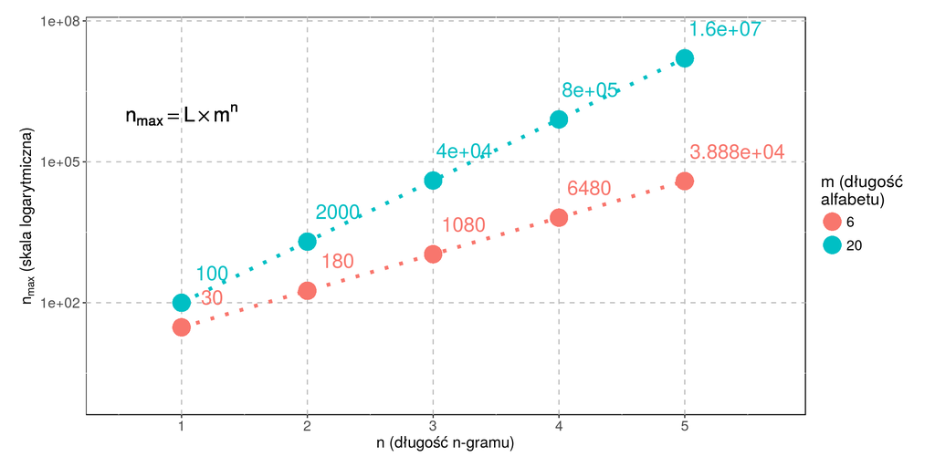

## Redukcja wymiarów - wybór n-gramów

n-gramy filtrowane są zwykle przy wykorzystaniu testów permutacyjnych.

Podczas testu permutacyjnego oznaczenia klas są losowo mieszane, a uzyskaną wartość danej statystyki (w tym przypad ku information gain) porównuje się z wartością tej statystyki dla danych oryginalnych.

\[ \textrm{p-value} = \frac{N_{T_P > T_R}}{N} \]

\(N_{T_P > T_R}\): wszystkie przypadki, kiedy \(T_P\) (permutowana statystyka testowa) przyjmuje wartości bardziej ekstremalne niż \(T_R\) (statystyka testowa dla danych oryginalnych).

\(N\): liczba wszystkich permutacji.

## QuiPT

Testy permutacyjne są bardzo wymagające obliczeniowo, dlatego też opracowałem **Qui**ck **P**ermutation **T**est, który pozwala wielokrotnie szybciej filtrować n-gramy.

QuiPT pozwala również na bardzo precyzyjne określanie p-value.

## Amyloidy - redukcja alfabetu

Stworzono 524 284 zredukowane alfabety o różnych długościach (od trzech do sześciu grup) wykorzystując metodę grupowań Warda na wybranych cechach fizykochemicznych z bazy właściwości aminokwasów AAIndex (Kawashima et al. 2008) w celu uzyskania alfabetu najlepiej dyskryminującego między białkami amyloidogennymi i nieamyloidogennymi.

## Najlepsze kodowanie

| Nazwa | Elementy |
| --- | --- |
| 1 | G |
| 2 | K, P, R |
| 3 | I, L, V |
| 4 | F, W, Y |
| 5 | A, C, H, M |
| 6 | D, E, N, Q, S, T |

## Najlepsze kodowanie

| Nazwa | Elementy |
| --- | --- |
| 1 | G |
| 2 | K, P, R |
| 3 | I, L, V |
| 4 | F, W, Y |
| 5 | A, C, H, M |
| 6 | D, E, N, Q, S, T |

Aminokwasy K, P, R nie powinny występować w obrębie hot spots (Paz and Serrano 2004).

## Najlepsze kodowanie

| Nazwa | Elementy |
| --- | --- |
| 1 | G |
| 2 | K, P, R |
| 3 | I, L, V |
| 4 | F, W, Y |
| 5 | A, C, H, M |
| 6 | D, E, N, Q, S, T |

Aminokwasy hydrofobowe są typowe dla hot spots (Doran et al. 2012).

## Informatywne n-gramy

Podczas analizy zidentyfikowano 65 najbardziej informatywnych n-gramów. Część z nich została potwierdzona eksperymentalnie (Paz and Serrano 2004).

## Informatywne n-gramy

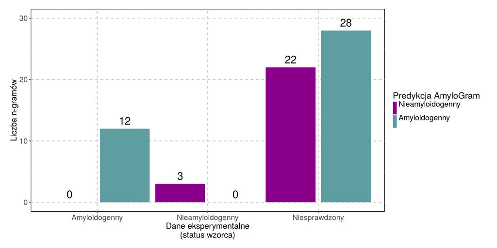

## AmyloGram

Najlepszy zredukowany alfabet wykorzystano do wyuczenia programu AmyloGram, nowego predyktora amyloidogenności opartego na n-gramach.

## AmyloGram - benchmark

| Software | AUC | MCC |
| --- | --- | --- |
| PASTA2 | 0.854996271439225 | 0.429123592940917 |
| FoldAmyloid | 0.735098185433756 | 0.45255292317694 |
| appnn | 0.834302759134974 | 0.582260193831285 |
| AmyloGram | 0.897153865274671 | 0.630749412736651 |

## Predykcja peptydów sygnałowych

Dzięki analize n-gramów jest również możliwe precyzyjne przewidywanie peptydów sygnałowych, n-końcowych sekwencji kierujących białka do lokalizacji pozakomórkowych.

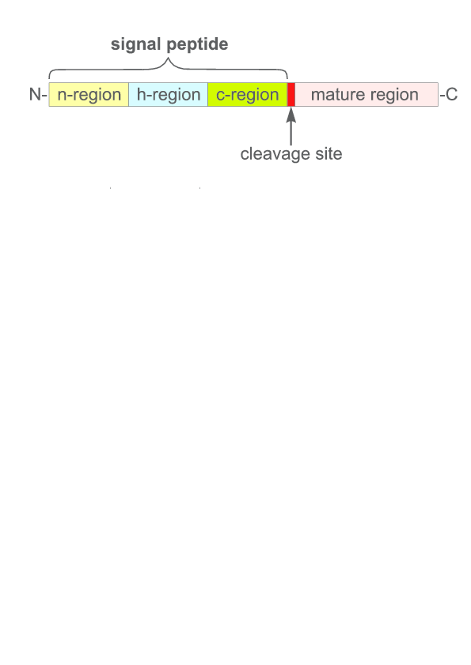

## Predykcja peptydów sygnałowych

Istniejące programy przewidujące peptydy sygnałowe gorzej radzą sobie z nietypowymi peptydami sygnałowymi, np. pochodzącymi z rodzaju *Plasmodium*, do którego należą pasożyty powodujące malarię (Cilingir, Broschat, and Lau 2012).

## Zastosowanie metody n-gramów: przewidywanie peptydów sygnałowych

Motywacja:

- rola peptydów sygnałowych w terapiach antymalarycznych,
- niska precyzja innych programów przewidujących peptydy sygnałowe *Plasmodium*,
- brak zachowania regionalnej struktury peptydu sygnałowego podczas predykcji.

## signalHsmm

W oparciu o metodę n-gramów opracowałem program signalHsmm, który rozpoznaje peptydy sygnałowe u eukariontów.

Mimo, że signalHsmm nie uczył się na sekwencjach peptydów sygnałowych *Plasmodium*, to jest je w stanie precyzyjnie rozpoznawać.

## signalHsmm - benchmark

| Software | AUC | MCC |
| --- | --- | --- |
| signalP 4.1 (no tm) | 0.866741 | 0.687152 |
| signalP 4.1 (tm) | 0.795093 | 0.619555 |
| signalP 3.0 (NN) | 0.893783 | 0.721977 |
| signalP 3.0 (HMM) | 0.773441 | 0.555306 |
| PrediSi | 0.64534 | 0.384944 |
| Philius | 0.770746 | 0.568437 |
| Phobius | 0.787984 | 0.589519 |
| signalHsmm-2010 (homol. red. 50%) | 0.938389 | 0.762052 |

## Predykcja peptydów sygnałowych

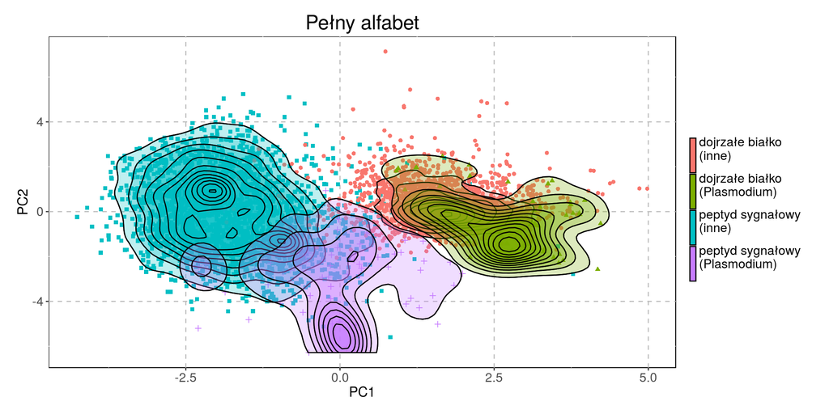

## Predykcja peptydów sygnałowych

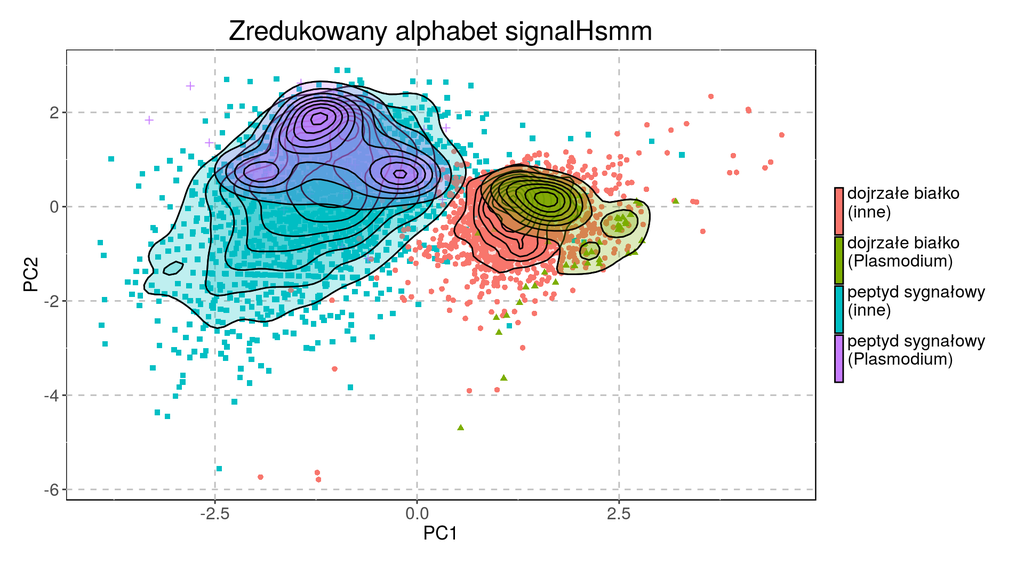

## Predykcja peptydów sygnałowych

Użycie zredukowanego alfabetu aminokwasowego pozwala na przewidywanie peptydów sygnałowych u organizmów rzadziej spotykanych w bazach danych.

## Podsumowanie

Interpretowalne analizy metodami n-gramowymi pozwalają na precyzyjniejsze przewidywanie właściwości sekwencji aminokwasowych.

[AmyloGram](http://www.smorfland.uni.wroc.pl/amylogram)  
[signalHsmm](http://www.smorfland.uni.wroc.pl/signalhsmm)

MKTVYIVAGLFVMLVQGSWQHAPQDTEENARSFPASQTEPLEDPDQINEDKRHSQGTFTSD  
YSKYLDSRRAQDFVQWLMNTKRNRNNIAKRHDEFERHAEGTFTSDVSSYLEGQAAKEFIAW  
LVKGRGRRDFPEEVAIAEELGRRHADGSFSDEMNTILDNLATRDFINWLIQTKITDKK

MGRRKIEIKRIENKSSRQVTFSKRRNGLIDKARQLSILCESSVAVVVVSASGKLYDSSSG  
DDISKIIDRYEIQHADELRALDLEEKIQNYLPHKELLETVQSKLEEPNVDNVSVDSLISL  
EEQLETALSVSRARKAELMMEYIESLKEKEKLLREENQVLASQMGKNTLLATDDERGMFP

## Perspektywy dalszych badań

- Opracowanie predykcji bakteryjnych peptydów sygnałowych.
- Weryfikacja eksperymentalna wzorców peptydów amyloidogennych i nieamyloidogennych wygenerowanych przez AmyloGram.
- Analiza n-gramów pochodzących z genomów mitochondrialnych różnych grup taksonomicznych.

## References

Cilingir, G., S. L. Broschat, and A. O. Lau. 2012. “ApicoAP: The First Computational Model for Identifying Apicoplast-Targeted Proteins in Multiple Species of Apicomplexa.” *PLoS ONE* 7 (5): e36598.

Doran, Todd M., Alissa J. Kamens, Nadia K. Byrnes, and Bradley L. Nilsson. 2012. “Role of Amino Acid Hydrophobicity, Aromaticity, and Molecular Volume on IAPP(20-29) Amyloid Self-Assembly.” *Proteins* 80 (4): 1053–65. doi:10.1002/prot.24007.

Familia, Carlos, Sarah R. Dennison, Alexandre Quintas, and David A. Phoenix. 2015. “Prediction of Peptide and Protein Propensity for Amyloid Formation.” *PLOS ONE* 10 (8): e0134679. doi:10.1371/journal.pone.0134679.

Garbuzynskiy, Sergiy O., Michail Yu Lobanov, and Oxana V. Galzitskaya. 2010. “FoldAmyloid: A Method of Prediction of Amyloidogenic Regions from Protein Sequence.” *Bioinformatics (Oxford, England)* 26 (3): 326–32. doi:10.1093/bioinformatics/btp691.

Kawashima, Shuichi, Piotr Pokarowski, Maria Pokarowska, Andrzej Kolinski, Toshiaki Katayama, and Minoru Kanehisa. 2008. “AAindex: Amino Acid Index Database, Progress Report 2008.” *Nucleic Acids Research* 36 (suppl 1): D202–D205. doi:10.1093/nar/gkm998.

Paz, Manuela López de la, and Luis Serrano. 2004. “Sequence Determinants of Amyloid Fibril Formation.” *Proceedings of the National Academy of Sciences* 101 (1): 87–92. doi:10.1073/pnas.2634884100.

Sawaya, Michael R., Shilpa Sambashivan, Rebecca Nelson, Magdalena I. Ivanova, Stuart A. Sievers, Marcin I. Apostol, Michael J. Thompson, et al. 2007. “Atomic Structures of Amyloid Cross-β Spines Reveal Varied Steric Zippers.” *Nature* 447 (7143): 453–57. doi:10.1038/nature05695.

Walsh, Ian, Flavio Seno, Silvio C. E. Tosatto, and Antonio Trovato. 2014. “PASTA 2.0: An Improved Server for Protein Aggregation Prediction.” *Nucleic Acids Research* 42 (W1): W301–W307. doi:10.1093/nar/gku399.